# [M1 MIASHS - TER] Visualisation du dataset TOUA

## Introduction

La première étape de notre projet de TER consiste à analyser trois jeux de données sur des arabidopsis pour comprendre comment des conditions de fort CO2 impactent la quantité de nutriments qu’elles produisent. Vous trouverez ci-après l’analyse du premier dataset dont nous disposons qui s’appelle TOUA.

## Données brutes

Voici les données fournies par nos commanditaires. Nous allons pouvoir leur appliquer plusieurs traitement afin de nous familiariser avec et de visualiser les dynamiques entre les différentes variables observées.

```r
toua <- read.csv2("TOUA_phenotypes.csv")
head(toua)
```

```
##   genotype Cu_eCo2 Cu_aCo2 Fe_eCo2 Fe_aCo2 Mg_eCo2 Mg_aCo2 Mn_eCo2 Mn_aCo2
## 1      1_2    5.93    7.74   56.61   87.01 2877.45 2758.60   48.45   41.91
## 2      1_3    6.92    7.91   73.42   62.29 2782.73 2992.24   50.18   45.19
## 3      1_4    7.78    8.05   68.88   82.91 3083.72 2975.63   48.33   41.94
## 4      1_6    9.34    8.47   81.39   85.88 2975.47 2914.94   57.24   40.64
## 5      1_7    7.99    8.42   76.48   86.71 2854.02 2882.91   49.52   48.48
## 6      1_8    7.07    9.07   69.73   85.97 2973.51 2939.51   47.58   51.47
##   Na_eCo2 Na_aCo2 Zn_eCo2 Zn_aCo2 C_eCo2 C_aCo2 N_eCo2 N_aCo2 N_change
## 1  961.87  852.11   26.20   35.76  27.67  38.37   3.73   6.37    -41.5
## 2  886.46  942.78   30.65   38.55  40.96  39.88   5.27   6.31    -16.4
## 3  685.74  643.56   37.77   44.87  37.96  37.05   5.75   6.43    -10.7
## 4  683.63  687.55   38.16   46.69  37.95  38.35   5.76   6.65    -13.4
## 5  659.94  641.13   37.54   44.84  41.37  38.71   5.38   6.55    -17.9
## 6  687.61  660.59   37.93   52.65  38.17  39.68   5.69   6.42    -11.3
##   aCN_ratio eCN_ratio eCN_aCN Fe_change Mg_change Mn_change Na_change Zn_change
## 1      6.03      7.42    23.2    -34.94      4.31     15.61     12.88    -26.73
## 2      6.32      7.77    22.9     17.86     -7.00     11.06     -5.97    -20.48
## 3      5.76      6.61    14.7    -16.93      3.63     15.21      6.55    -15.82
## 4      5.77      6.59    14.3     -5.23      2.08     40.84     -0.57    -18.27
## 5      5.91      7.70    30.2    -11.80     -1.00      2.15      2.93    -16.27
## 6      6.18      6.71     8.4    -18.90      1.16     -7.54      4.09    -27.97
```

### Rajout de la colonne de Changement pour le Carbonne et le cuivre

Nous avons commencé par rajouter deux variables de variation qui pouvaient être facilement calculées :

```r
toua$C_change <- round(((toua$C_eCo2-toua$C_aCo2)/toua$C_aCo2)*100, digits = 2)
toua$Cu_change <- round(((toua$Cu_eCo2-toua$Cu_aCo2)/toua$Cu_aCo2)*100, digits = 2)
```

## Identification des outliers

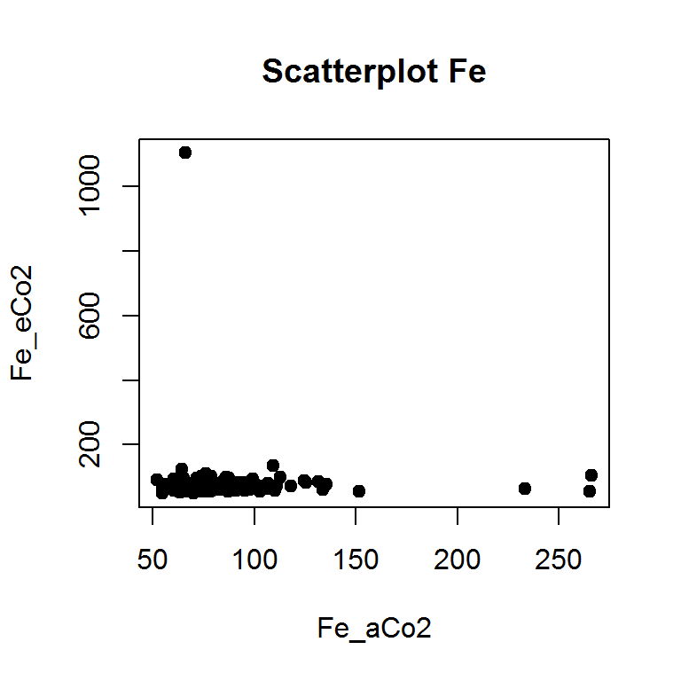

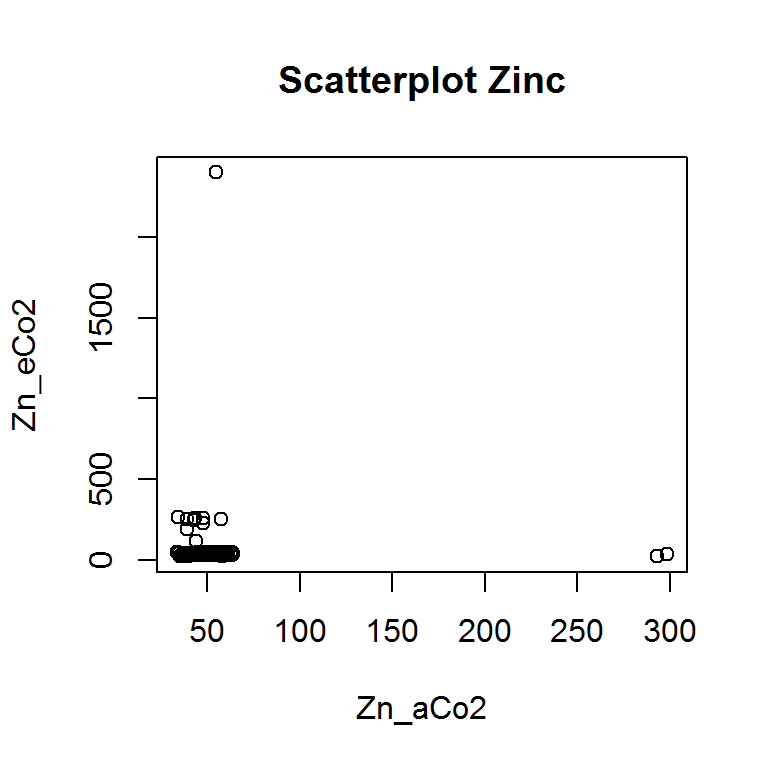

Comme le montrent ces deux Scatter plots,certaines valeurs pour certains éléments sont très singulières, et après discussion avec nos encadrants nous en avons conclu qu’il s’agit d’erreurs de mesures qui ne peuvent pas exister en réalité. Nous allons donc les supprimer.

## Suppression des outliers

```r
toua_no_out <- toua[1:17]
k= 3
for (i in 2:17) {
  binf <- median(toua[,i]) - k* mad(toua[,i])
  bsup <- median(toua[,i]) + k* mad(toua[,i])
  outlier_idx <- which(toua_no_out[,i] < binf | toua_no_out[,i] > bsup)
    if (length(outlier_idx) == 0) {
      toua_no_out = toua_no_out
    }
    else{
      toua_no_out = toua_no_out[-c(outlier_idx),]
      }
  #print(outlier_idx)
  }
```

Nous créons aussi un dataFrame qui garde les lignes qui contiennent des observations outlier et qui remplace juste ces observations par des NA’s.

```r
library(naniar)
k= 3

toua_no_out_NA <- toua[1:17]
for (i in 2:17) {
  binf <- median(toua[,i]) - k* mad(toua[,i])
  bsup <- median(toua[,i]) + k* mad(toua[,i])
  outlier_idx <- which(toua_no_out_NA[,i] < binf | toua_no_out_NA[,i] > bsup)
  if (length(outlier_idx) == 0) {
    toua_no_out_NA = toua_no_out_NA
  }
  else{
    toua_no_out_NA[c(outlier_idx),i] =NA
  }
}
```

### Calcul des colonnes de variation sans les outliers

Comme nous avons supprimé les lignes contenant des outliers, ils nous faut recalculer les colonnes de variation pour chaque élément, ce qui nous donne ce nouveau DataFrame :

```
##   genotype Cu_eCo2 Cu_aCo2 Fe_eCo2 Fe_aCo2 Mg_eCo2 Mg_aCo2 Mn_eCo2 Mn_aCo2
## 1      1_2    5.93    7.74   56.61   87.01 2877.45 2758.60   48.45   41.91
## 2      1_3    6.92    7.91   73.42   62.29 2782.73 2992.24   50.18   45.19
## 3      1_4    7.78    8.05   68.88   82.91 3083.72 2975.63   48.33   41.94
## 4      1_6    9.34    8.47   81.39   85.88 2975.47 2914.94   57.24   40.64
## 5      1_7    7.99    8.42   76.48   86.71 2854.02 2882.91   49.52   48.48
## 6      1_8    7.07    9.07   69.73   85.97 2973.51 2939.51   47.58   51.47
##   Na_eCo2 Na_aCo2 Zn_eCo2 Zn_aCo2 C_eCo2 C_aCo2 N_eCo2 N_aCo2 N_change
## 1  961.87  852.11   26.20   35.76     NA  38.37     NA   6.37       NA
## 2  886.46  942.78   30.65   38.55  40.96  39.88   5.27   6.31   -16.48
## 3  685.74  643.56   37.77   44.87  37.96  37.05   5.75   6.43   -10.58
## 4  683.63  687.55   38.16   46.69  37.95  38.35   5.76   6.65   -13.38
## 5  659.94  641.13   37.54   44.84  41.37  38.71   5.38   6.55   -17.86
## 6  687.61  660.59   37.93   52.65  38.17  39.68   5.69   6.42   -11.37
##   Fe_change Mg_change Mn_change Na_change Zn_change C_change Cu_change
## 1    -34.94      4.31     15.60     12.88    -26.73       NA    -23.39
## 2     17.87     -7.00     11.04     -5.97    -20.49     2.71    -12.52
## 3    -16.92      3.63     15.24      6.55    -15.82     2.46     -3.35
## 4     -5.23      2.08     40.85     -0.57    -18.27    -1.04     10.27
## 5    -11.80     -1.00      2.15      2.93    -16.28     6.87     -5.11
## 6    -18.89      1.16     -7.56      4.09    -27.96    -3.81    -22.05
```

### Passage en format long avec gather

Pour pouvoir réaliser certaines visualisations, nous avons besoin de mettre nos données au format long, ce qui nous donne le DataFrame suivant :

```
##   genotype  element valeur
## 1      1_2 N_change     NA
## 2      1_3 N_change -16.48
## 3      1_4 N_change -10.58
## 4      1_6 N_change -13.38
## 5      1_7 N_change -17.86
## 6      1_8 N_change -11.37
```

## Première Visualisation : Variation moyenne des mesures entre le aCO2 et le eCO2

Nous avons ici voulu reproduire une visualisation qui avait été faite dans le cas du riz pour montrer la variation de chaque élément quand la plante est en condition de fort CO2 et quand elle est en condition de CO2 ambiant.

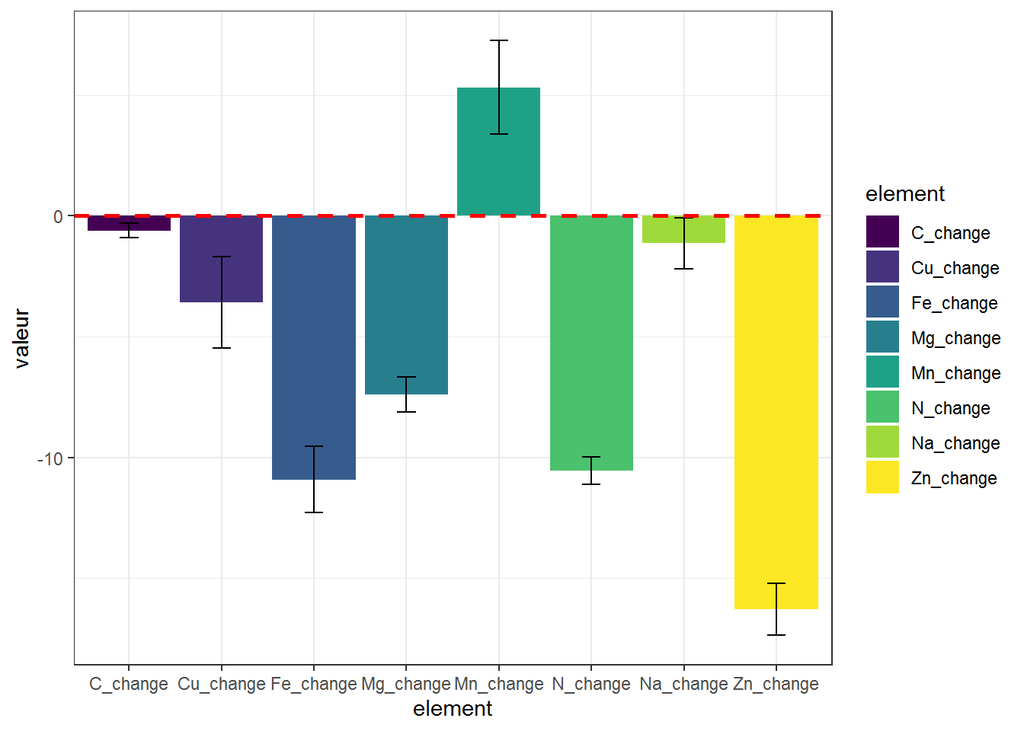

```r
ggplot(toua_chl, aes(element, valeur, fill = element))+
  stat_summary(fun = "mean", geom = "bar") +
  stat_summary(fun.data = mean_se , geom = "errorbar", width = 0.2)+
  geom_hline(yintercept = 0, color = "red", linetype = "dashed", size = 1) +
  scale_fill_viridis_d() +
  scale_color_viridis_d() +
  theme_bw()
```

Observations :

1. On n’observe pas vraiment de hausse des taux de Carbonne mesurés (contrairement à ce qui a été vu chez le riz par exemple) mais cela s’explique par le fait que la mesure est rapportée au poids de la plante. Ce résultat est donc plutôt normal.
2. On observe une forte diminution du zinc et du fer, deux nutriments essentiels dans l’alimentation, ainsi qu’une grande diminution de l’azote. On observe des diminutions moins marquées mais néanmoins notables pour le magnésium et le cuivre. Enfin, on peut voir une augmentation du manganèse assez importante pour être soulignée.

### Scatter Plots

Afin de visualiser d’une autre façon si il y a une perte de certains éléments quand la plante est en condition de fort CO2, nous avons créé des scatter plots.

### Scatter Plots des éléments e/a

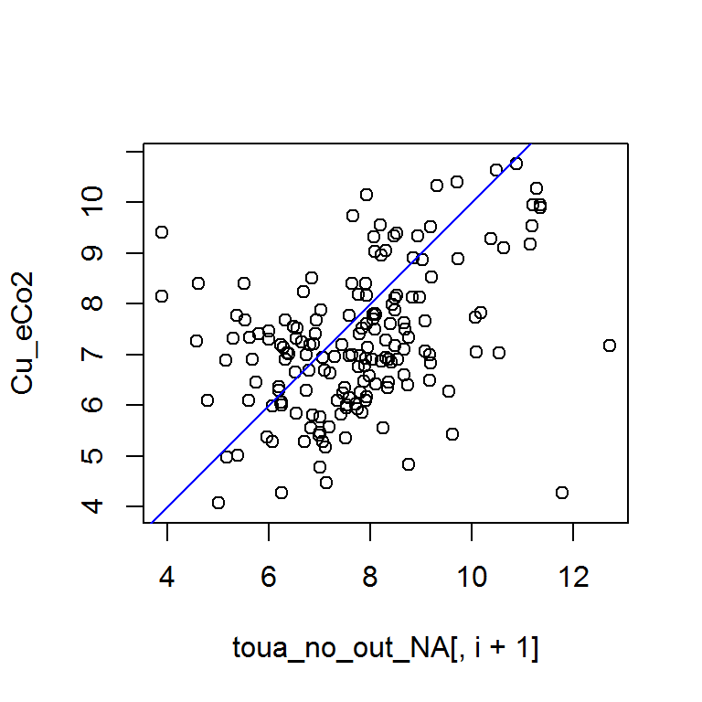

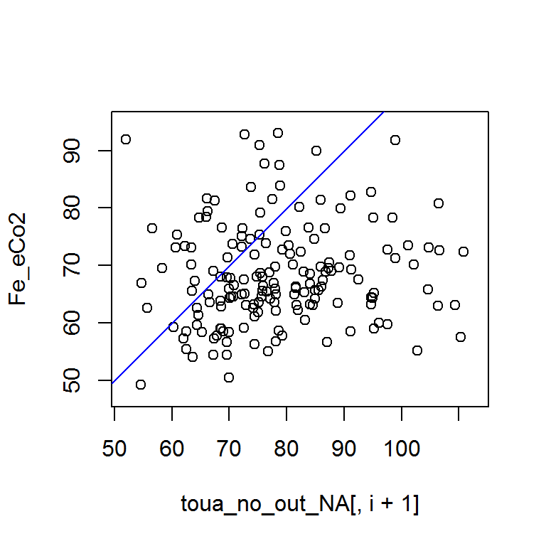

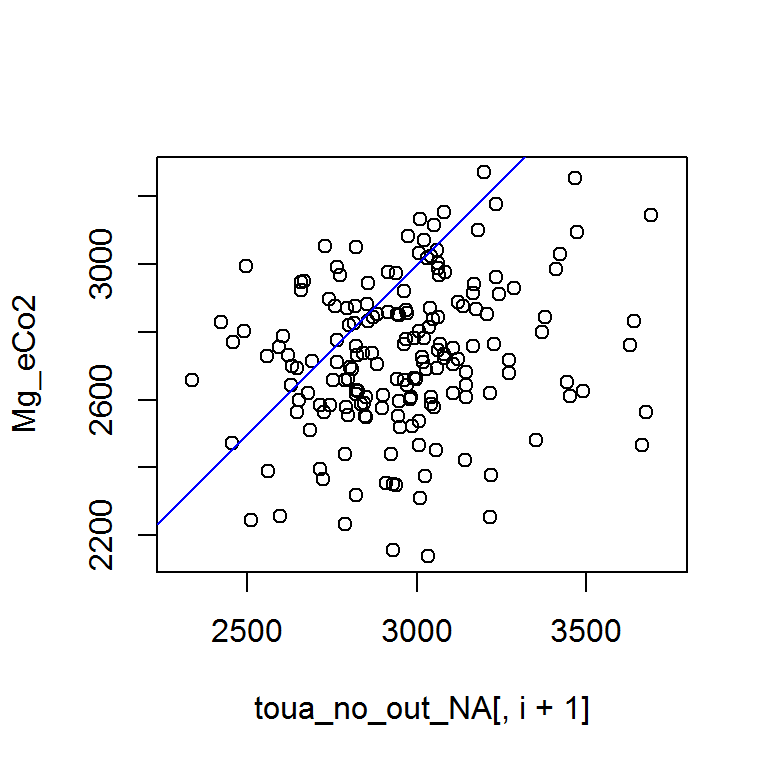

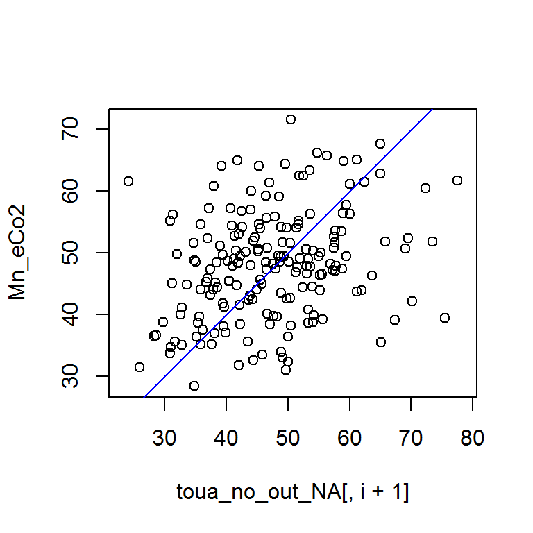

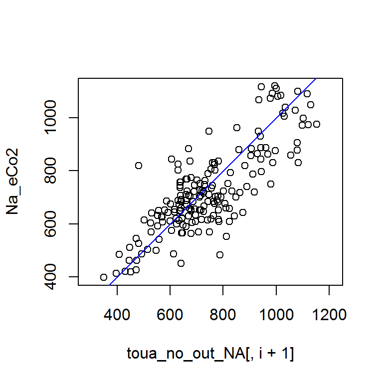

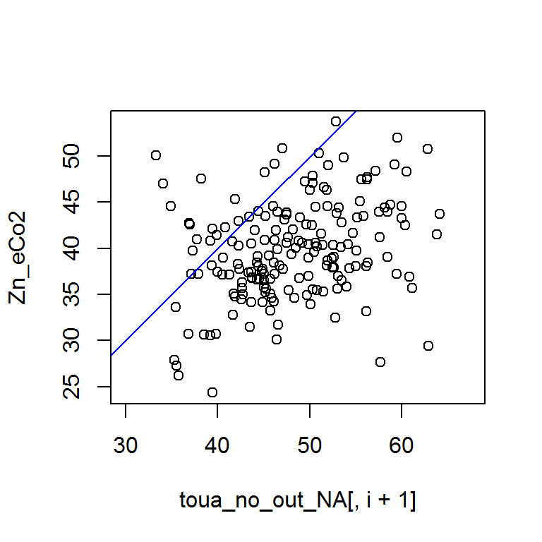

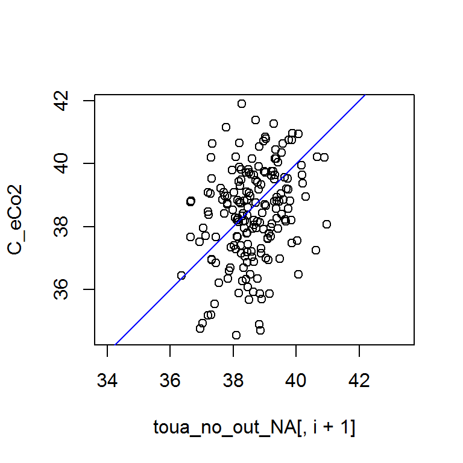

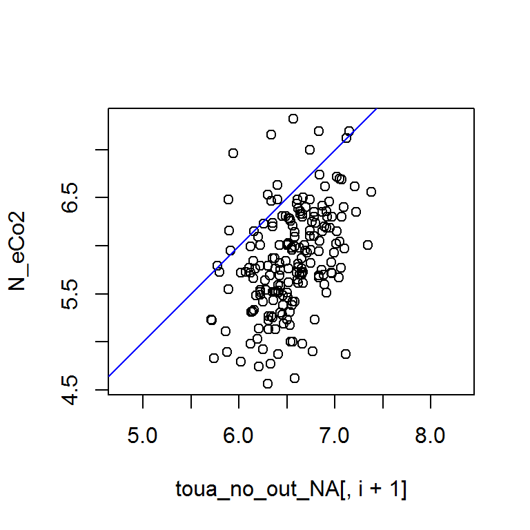

```r
i = 2
while (i < 17) {
plot(toua_no_out_NA[,i+1], toua_no_out_NA[,i], xlab = names(toua_no_out_NA[,i+1]), ylab = names(toua_no_out_NA[i]),asp=1)
abline(0,1, col = "blue")
i = i + 2}
```

La ligne bleue représente la droite d’ordonnée à l’origine 0 et de coefficient directeur 1. Nous pouvons déjà constater visuellement que le Fer, le Magnénium, le zinc et l’azote ont l’air de diminuer en condition de CO2 élevé. Nous vérifierons plus tard avec plusieurs tests si nos intuitions sont correctes.

## Distribution des données : Histogrammes et Violin plots

### Violin plots

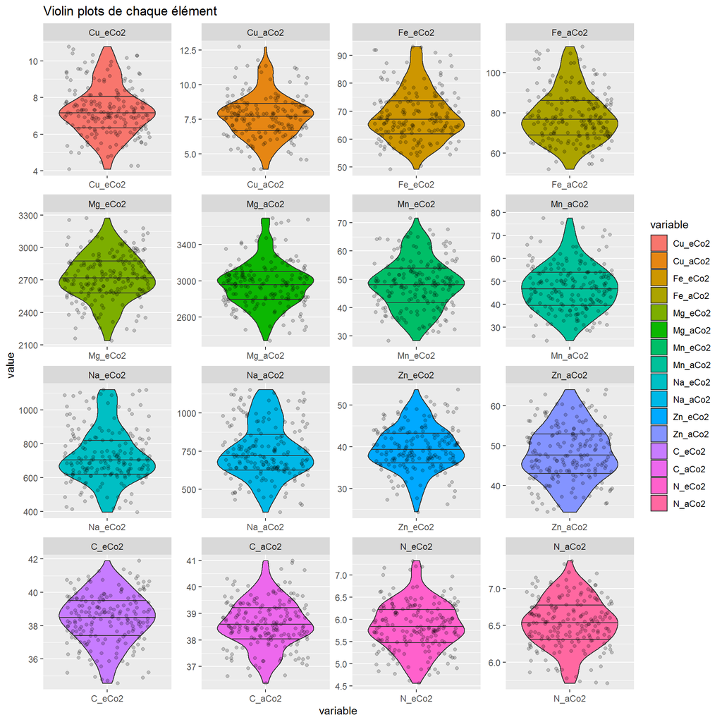

### Histogrammes

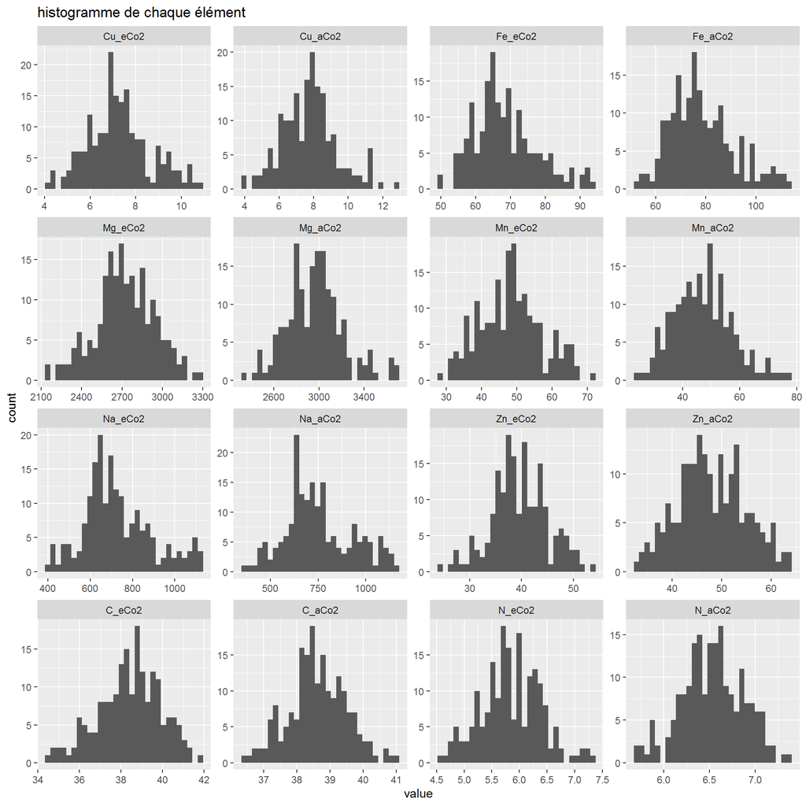

Après ces deux visualisations nous pouvons remarquer que les distributions ont l’air pour la plupart normales mais que des doutes quand à leur normalité persistent.

## Tests de normalité : Test de Shapiro

Dans le but de choisir des tests sur la moyenne et sur la variance adaptés à nos données, nous avons commencé par réaliser un test de normalité, ici le test de Shapiro.

Voici les p-values pour la distribution de chaque élément :

```
## [1] "Test de Shapiro entre les données Cu_eCo2"
## [1] 0.02499918
## [1] "Test de Shapiro entre les données Cu_aCo2"
## [1] 0.0588103
## [1] "Test de Shapiro entre les données Fe_eCo2"
## [1] 0.0003713669
## [1] "Test de Shapiro entre les données Fe_aCo2"
## [1] 0.0004330461
## [1] "Test de Shapiro entre les données Mg_eCo2"
## [1] 0.7692799
## [1] "Test de Shapiro entre les données Mg_aCo2"
## [1] 0.0104662
## [1] "Test de Shapiro entre les données Mn_eCo2"
## [1] 0.121463
## [1] "Test de Shapiro entre les données Mn_aCo2"
```

[output cut: 17 more lines]

### Test de significativité sur les moyennes : Wilcoxon

Ici on a choisi un test de Wilcoxon (car on ne respecte pas les pré-requis pour un test paramétrique pour toutes nos variables) pour des valeurs paired, car la mesure en Co2 ambiant et élevé sont réalisées sur les mêmes génotypes. Vous trouverez ci dessous des violin plots deux à deux et la p-value de chaque paire avec le test de Wilcoxon.

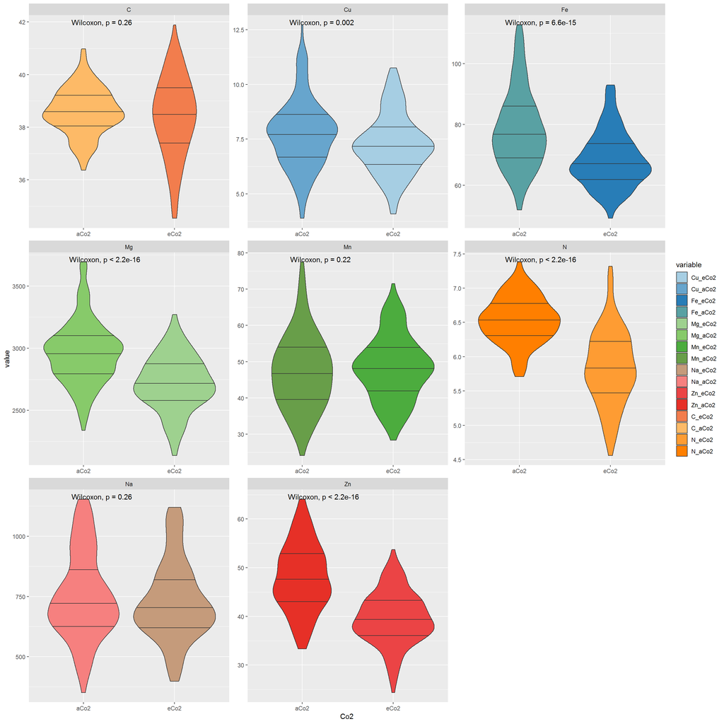

### Autre visualisation du résultat du test de Wilcoxon

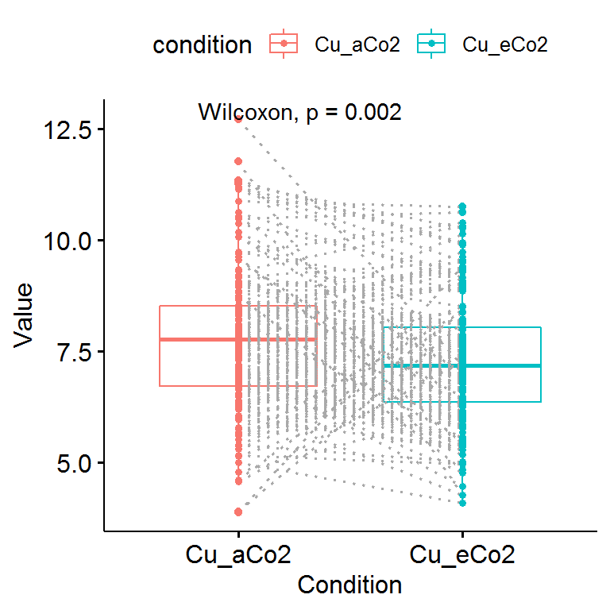

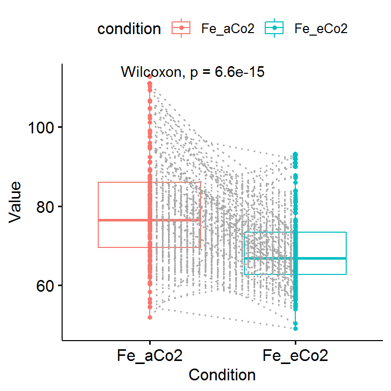

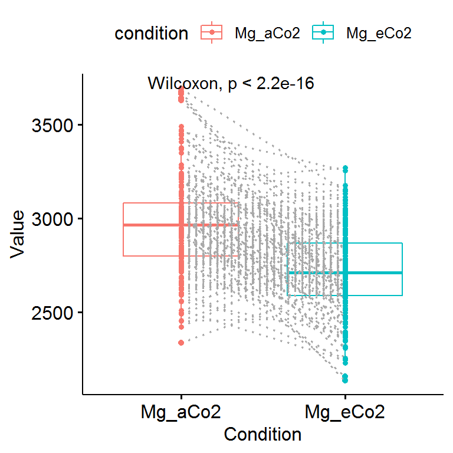

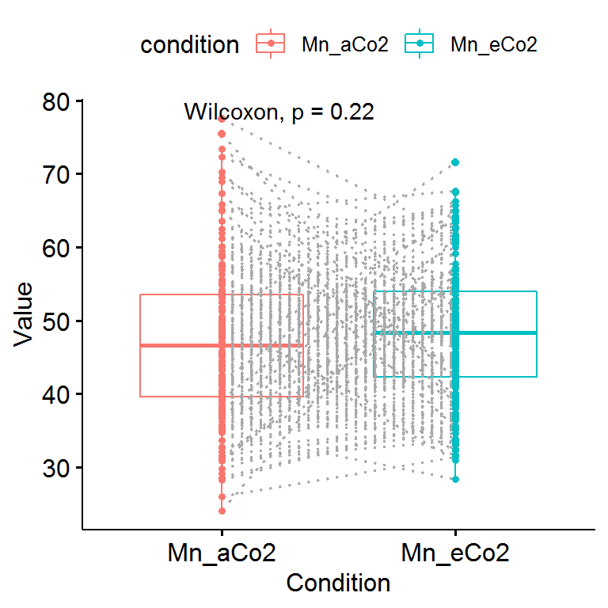

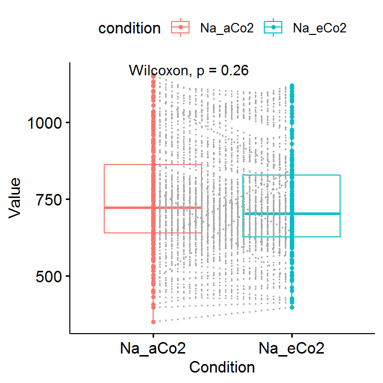

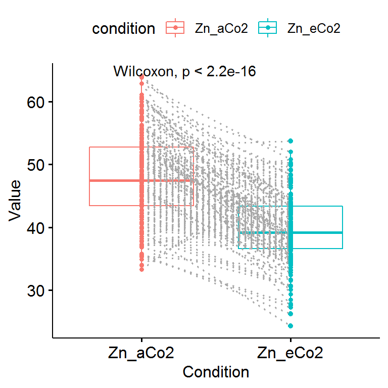

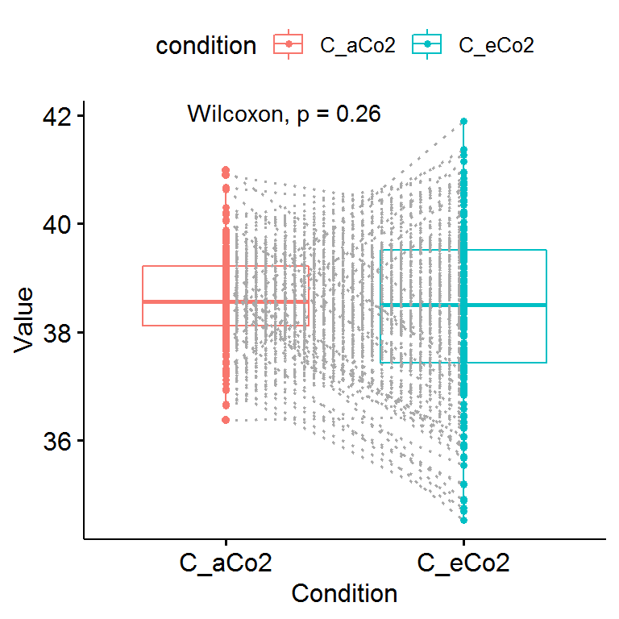

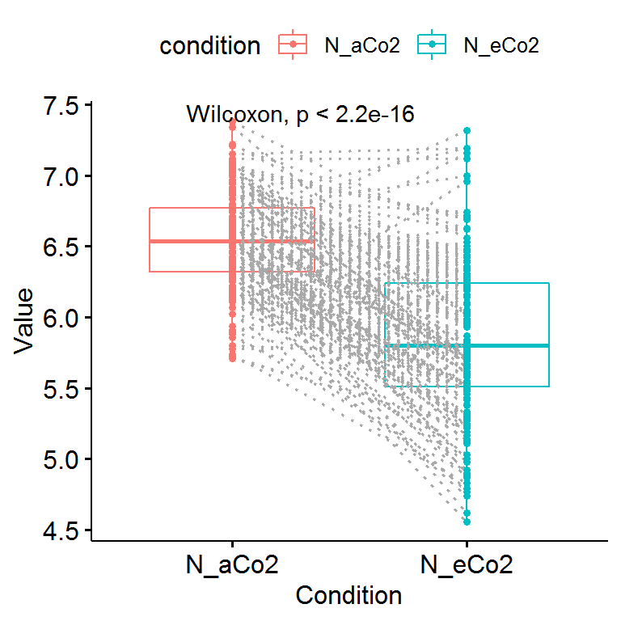

```r
i=2
while (i < 17) {
  plot_paired <- ggpaired(toua_no_out_NA, cond1 = names(toua_no_out_NA[i+1]) , cond2 = names(toua_no_out_NA[i]),
           line.color = "dark gray", line.size = 0.6, color = "condition",
           width = 0.7, linetype = "dotted" ,
           palette = "aas")+
    stat_compare_means()
  print(plot_paired)
  i = i+2
}
```

### Test de significativité sur les moyennes pour les répartitions normales : Student

```
## [1] "Test de Student entre les données Mg_aCo2 et Mg_eCo2"
```

```
## [1] "p-value =  6.26357368116802e-20"
```

```
## [1] "Test de Student entre les données Mn_aCo2 et Mn_eCo2"
```

```
## [1] "p-value =  0.369331701179017"
```

```
## [1] "Test de Student entre les données Zn_aCo2 et Zn_eCo2"
```

```
## [1] "p-value =  4.25039545018642e-35"
```

```
## [1] "Test de Student entre les données C_aCo2 et C_eCo2"
```

```
## [1] "p-value =  0.0294538192927533"
```

```
## [1] "Test de Student entre les données N_aCo2 et N_eCo2"
```

```
## [1] "p-value =  2.1996628562614e-45"
```

### Test de significativité sur les variances pour les répartitions non normales : Levene

```
## [1] "Test de Levene entre les données Cu_eCo2 et Cu_aCo2"
## [1] "p-value =  0.144255904729298"
## [1] "Test de Levene entre les données Fe_eCo2 et Fe_aCo2"
## [1] "p-value =  0.000112939036816563"
## [1] "Test de Levene entre les données Mg_eCo2 et Mg_aCo2"
## [1] "p-value =  0.226226348188927"
## [1] "Test de Levene entre les données Mn_eCo2 et Mn_aCo2"
## [1] "p-value =  0.0280436799801609"
## [1] "Test de Levene entre les données Na_eCo2 et Na_aCo2"
## [1] "p-value =  0.17428375573344"
## [1] "Test de Levene entre les données Zn_eCo2 et Zn_aCo2"
## [1] "p-value =  0.000397065883813397"
## [1] "Test de Levene entre les données C_eCo2 et C_aCo2"
## [1] "p-value =  9.01229396211654e-11"
## [1] "Test de Levene entre les données N_eCo2 et N_aCo2"
## [1] "p-value =  1.45823375269711e-08"
```

```r
#sapply(reg_no_out_NA, var(na.rm=TRUE))
sapply(toua_no_out_NA, function(x)  var=var(x,na.rm=TRUE))
```

```
##     genotype      Cu_eCo2      Cu_aCo2      Fe_eCo2      Fe_aCo2      Mg_eCo2
##           NA 1.867665e+00 2.471747e+00 8.206277e+01 1.643495e+02 4.807749e+04
##      Mg_aCo2      Mn_eCo2      Mn_aCo2      Na_eCo2      Na_aCo2      Zn_eCo2
## 6.345425e+04 7.727487e+01 1.064065e+02 2.628538e+04 3.151119e+04 2.916861e+01
##      Zn_aCo2       C_eCo2       C_aCo2       N_eCo2       N_aCo2     N_change
## 4.703503e+01 2.277961e+00 7.702393e-01 2.931335e-01 1.135024e-01 5.962583e+01
##    Fe_change    Mg_change    Mn_change    Na_change    Zn_change     C_change
## 3.067716e+02 9.356006e+01 6.908606e+02 2.063435e+02 2.058335e+02 1.547949e+01
##    Cu_change
## 6.080550e+02
```

### Test de significativité sur les variances pour les répartitions normales : Fisher

```
## [1] "Test de Fisher entre les données Mg_aCo2 et Mg_eCo2"
```

```
## [1] "p-value =  0.0608067418001621"
```

```
## [1] "Test de Fisher entre les données Mn_aCo2 et Mn_eCo2"
```

```
## [1] "p-value =  0.0291035090399823"
```

```
## [1] "Test de Fisher entre les données Zn_aCo2 et Zn_eCo2"
```

```
## [1] "p-value =  0.00127077803071707"
```

```
## [1] "Test de Fisher entre les données C_aCo2 et C_eCo2"
```

```
## [1] "p-value =  4.25636509654163e-13"
```

```
## [1] "Test de Fisher entre les données N_aCo2 et N_eCo2"
```

```
## [1] "p-value =  1.36861902513215e-10"
```